```python
from nbdev.showdoc import *
from PIL import Image
```

## Basics

`Tensor.__array_eq__`[[source]](https://github.com/fastai/fastai2/tree/master/fastai2/torch_core.py#L26)

> `Tensor.__array_eq__`(**`b`**)

`tensor`[[source]](https://github.com/fastai/fastai2/tree/master/fastai2/torch_core.py#L36)

> `tensor`(**`x`**, *`rest`, **`kwargs`)

Like `torch.as_tensor`, but handle lists too, and can pass multiple vector elements directly.

```python
test_eq(tensor(torch.tensor([1,2,3])), torch.tensor([1,2,3]))
test_eq(tensor(array([1,2,3])), torch.tensor([1,2,3]))
test_eq(tensor(1,2,3), torch.tensor([1,2,3]))
test_eq_type(tensor(1.0), torch.tensor(1.0))
```

`set_seed`[[source]](https://github.com/fastai/fastai2/tree/master/fastai2/torch_core.py#L51)

> `set_seed`(**`s`**)

Set random seed for `random`, `torch`, and `numpy` (where available)

```python
set_seed(2*33)
a1 = np.random.random()
a2 = torch.rand(())
a3 = random.random()
set_seed(2*33)
b1 = np.random.random()
b2 = torch.rand(())
b3 = random.random()
test_eq(a1,b1)
test_eq(a2,b2)
test_eq(a3,b3)
```

`unsqueeze`[[source]](https://github.com/fastai/fastai2/tree/master/fastai2/torch_core.py#L60)

> `unsqueeze`(**`x`**, **`dim`**=*`-1`*, **`n`**=*`1`*)

Same as `torch.unsqueeze` but can add `n` dims

```python
t = tensor([1])
t2 = unsqueeze(t, n=2)
test_eq(t2,t[:,None,None])
```

`unsqueeze_`[[source]](https://github.com/fastai/fastai2/tree/master/fastai2/torch_core.py#L66)

> `unsqueeze_`(**`x`**, **`dim`**=*`-1`*, **`n`**=*`1`*)

Same as `torch.unsqueeze_` but can add `n` dims

```python
t = tensor([1])
unsqueeze_(t, n=2)
test_eq(t, tensor([1]).view(1,1,1))
```

`apply`[[source]](https://github.com/fastai/fastai2/tree/master/fastai2/torch_core.py#L76)

> `apply`(**`func`**, **`x`**, *`args`, **`kwargs`)

Apply `func` recursively to `x`, passing on args

`maybe_gather`[[source]](https://github.com/fastai/fastai2/tree/master/fastai2/torch_core.py#L84)

> `maybe_gather`(**`x`**, **`axis`**=*`0`*)

Gather copies of `x` on `axis` is training is distributed

`to_detach`[[source]](https://github.com/fastai/fastai2/tree/master/fastai2/torch_core.py#L93)

> `to_detach`(**`b`**, **`cpu`**=*`True`*, **`gather`**=*`True`*)

Recursively detach lists of tensors in `b`; put them on the CPU if `cpu=True`.

`gather` only applies during distributed training and the result tensor will be the one gathered accross processes if `gather=True` (as a result, the batch size will be multiplied by the number of processes).

`to_half`[[source]](https://github.com/fastai/fastai2/tree/master/fastai2/torch_core.py#L103)

> `to_half`(**`b`**)

Recursively map lists of tensors in `b` to FP16.

`to_float`[[source]](https://github.com/fastai/fastai2/tree/master/fastai2/torch_core.py#L108)

> `to_float`(**`b`**)

Recursively map lists of int tensors in `b` to float.

`default_device`[[source]](https://github.com/fastai/fastai2/tree/master/fastai2/torch_core.py#L117)

> `default_device`(**`use_cuda`**=*`-1`*)

Return or set default device; `use_cuda`: None - CUDA if available; True - error if not availabe; False - CPU

```python
#cuda
_td = torch.device(torch.cuda.current_device())
test_eq(default_device(None), _td)
test_eq(default_device(True), _td)
test_eq(default_device(False), torch.device('cpu'))
default_device(None);
```

`to_device`[[source]](https://github.com/fastai/fastai2/tree/master/fastai2/torch_core.py#L125)

> `to_device`(**`b`**, **`device`**=*`None`*)

Recursively put `b` on `device`.

```python
t = to_device((3,(tensor(3),tensor(2))))
t1,(t2,t3) = t
test_eq_type(t,(3,(tensor(3).cuda(),tensor(2).cuda())))
test_eq(t2.type(), "torch.cuda.LongTensor")
test_eq(t3.type(), "torch.cuda.LongTensor")
```

`to_cpu`[[source]](https://github.com/fastai/fastai2/tree/master/fastai2/torch_core.py#L132)

> `to_cpu`(**`b`**)

Recursively map lists of tensors in `b` to the cpu.

```python
t3 = to_cpu(t3)
test_eq(t3.type(), "torch.LongTensor")
test_eq(t3, 2)
```

`to_np`[[source]](https://github.com/fastai/fastai2/tree/master/fastai2/torch_core.py#L137)

> `to_np`(**`x`**)

Convert a tensor to a numpy array.

```python
t3 = to_np(t3)
test_eq(type(t3), np.ndarray)
test_eq(t3, 2)
```

`to_concat`[[source]](https://github.com/fastai/fastai2/tree/master/fastai2/torch_core.py#L142)

> `to_concat`(**`xs`**, **`dim`**=*`0`*)

Concat the element in `xs` (recursively if they are tuples/lists of tensors)

```python
test_eq(to_concat([tensor([1,2]), tensor([3,4])]), tensor([1,2,3,4]))
test_eq(to_concat([tensor([[1,2]]), tensor([[3,4]])], dim=1), tensor([[1,2,3,4]]))
test_eq_type(to_concat([(tensor([1,2]), tensor([3,4])), (tensor([3,4]), tensor([5,6]))]), (tensor([1,2,3,4]), tensor([3,4,5,6])))
test_eq_type(to_concat([[tensor([1,2]), tensor([3,4])], [tensor([3,4]), tensor([5,6])]]), [tensor([1,2,3,4]), tensor([3,4,5,6])])
test_eq_type(to_concat([(tensor([1,2]),), (tensor([3,4]),)]), (tensor([1,2,3,4]),))

test_eq(to_concat([tensor([[1,2]]), tensor([[3,4], [5,6]])], dim=1), [tensor([1]),tensor([3, 5]),tensor([4, 6])])
```

## Tensor subtypes

`class` `TensorBase`[[source]](https://github.com/fastai/fastai2/tree/master/fastai2/torch_core.py#L151)

> `TensorBase`(**`x`**, **`kwargs`) :: `Tensor`

`class` `TensorCategory`[[source]](https://github.com/fastai/fastai2/tree/master/fastai2/torch_core.py#L193)

> `TensorCategory`(**`x`**, **`kwargs`) :: `TensorBase`

`class` `TensorMultiCategory`[[source]](https://github.com/fastai/fastai2/tree/master/fastai2/torch_core.py#L196)

> `TensorMultiCategory`(**`x`**, **`kwargs`) :: `TensorCategory`

```python
class _T(TensorBase): pass

t = _T(range(5))
test_eq(t[0], 0)
test_eq_type(t.gi(0), _T(0))
test_eq_type(t.gi(slice(2)), _T([0,1]))
test_eq_type(t+1, _T(range(1,6)))

test_eq(type(pickle.loads(pickle.dumps(t))), _T)
```

```python
t = tensor([1,2,3])
m = TensorBase([False,True,True])
test_eq(t[m], tensor([2,3]))

t = tensor([[1,2,3],[1,2,3]])
m = TensorBase([[False,True,True],
                [False,True,True]])
test_eq(t[m], tensor([2,3,2,3]))
```

```python
t = TensorBase([[1,2,3],[1,2,3]], a=1)
test_eq(t._meta, {'a': 1})
x = retain_type(tensor([4,5,6]), t)
test_eq(x._meta, {'a': 1})
```

`class` `TensorImageBase`[[source]](https://github.com/fastai/fastai2/tree/master/fastai2/torch_core.py#L199)

> `TensorImageBase`(**`x`**, **`kwargs`) :: `TensorBase`

`class` `TensorImage`[[source]](https://github.com/fastai/fastai2/tree/master/fastai2/torch_core.py#L205)

> `TensorImage`(**`x`**, **`kwargs`) :: `TensorImageBase`

`class` `TensorImageBW`[[source]](https://github.com/fastai/fastai2/tree/master/fastai2/torch_core.py#L208)

> `TensorImageBW`(**`x`**, **`kwargs`) :: `TensorImage`

`class` `TensorMask`[[source]](https://github.com/fastai/fastai2/tree/master/fastai2/torch_core.py#L211)

> `TensorMask`(**`x`**, **`kwargs`) :: `TensorImageBase`

```python
im = Image.open(TEST_IMAGE)
```

```python
im_t = TensorImage(array(im))
test_eq(type(im_t), TensorImage)
```

```python
im_t2 = TensorMask(tensor(1))
test_eq(type(im_t2), TensorMask)
test_eq(im_t2, tensor(1))
```

```python
ax = im_t.show(figsize=(2,2))
```

[output not shown]

```python
test_fig_exists(ax)
```

`L.tensored`[[source]](https://github.com/fastai/fastai2/tree/master/fastai2/torch_core.py#L214)

> `L.tensored`()

`mapped(tensor)`

There are shortcuts for `torch.stack` and `torch.cat` if your `L` contains tensors or something convertible. You can manually convert with `tensored`.

```python
t = L(([1,2],[3,4]))
test_eq(t.tensored(), [tensor(1,2),tensor(3,4)])
```

`L.stack`[[source]](https://github.com/fastai/fastai2/tree/master/fastai2/torch_core.py#L218)

> `L.stack`(**`dim`**=*`0`*)

Same as `torch.stack`

```python
test_eq(t.stack(), tensor([[1,2],[3,4]]))
```

`L.cat`[[source]](https://github.com/fastai/fastai2/tree/master/fastai2/torch_core.py#L222)

> `L.cat`(**`dim`**=*`0`*)

Same as `torch.cat`

```python
test_eq(t.cat(), tensor([1,2,3,4]))
```

## Chunks

`concat`[[source]](https://github.com/fastai/fastai2/tree/master/fastai2/torch_core.py#L228)

> `concat`(*`ls`)

Concatenate tensors, arrays, lists, or tuples

```python
a,b,c = [1],[1,2],[1,1,2]
test_eq(concat(a,b), c)
test_eq_type(concat(tuple (a),tuple (b)), tuple (c))
test_eq_type(concat(array (a),array (b)), array (c))
test_eq_type(concat(tensor(a),tensor(b)), tensor(c))
test_eq_type(concat(TensorBase(a),TensorBase(b)), TensorBase(c))
test_eq_type(concat([1,1],1), [1,1,1])
test_eq_type(concat(1,1,1), L(1,1,1))
test_eq_type(concat(L(1,2),1), L(1,2,1))
```

`class` `Chunks`[[source]](https://github.com/fastai/fastai2/tree/master/fastai2/torch_core.py#L241)

> `Chunks`(**`chunks`**, **`lens`**=*`None`*)

Slice and int indexing into a list of lists

```python
docs = L(list(string.ascii_lowercase[a:b]) for a,b in ((0,3),(3,7),(7,8),(8,16),(16,24),(24,26)))

b = Chunks(docs)
test_eq([b[ o] for o in range(0,5)], ['a','b','c','d','e'])
test_eq([b[-o] for o in range(1,6)], ['z','y','x','w','v'])
test_eq(b[6:13], 'g,h,i,j,k,l,m'.split(','))
test_eq(b[20:77], 'u,v,w,x,y,z'.split(','))
test_eq(b[:5], 'a,b,c,d,e'.split(','))
test_eq(b[:2], 'a,b'.split(','))
```

```python
t = torch.arange(26)
docs = L(t[a:b] for a,b in ((0,3),(3,7),(7,8),(8,16),(16,24),(24,26)))
b = Chunks(docs)
test_eq([b[ o] for o in range(0,5)], range(0,5))
test_eq([b[-o] for o in range(1,6)], [25,24,23,22,21])
test_eq(b[6:13], torch.arange(6,13))
test_eq(b[20:77], torch.arange(20,26))
test_eq(b[:5], torch.arange(5))
test_eq(b[:2], torch.arange(2))
```

```python
docs = L(TensorBase(t[a:b]) for a,b in ((0,3),(3,7),(7,8),(8,16),(16,24),(24,26)))
b = Chunks(docs)
test_eq_type(b[:2], TensorBase(range(2)))
test_eq_type(b[:5], TensorBase(range(5)))
test_eq_type(b[9:13], TensorBase(range(9,13)))
```

## Other functions

`one_param`[[source]](https://github.com/fastai/fastai2/tree/master/fastai2/torch_core.py#L269)

> `one_param`(**`m`**)

First parameter in `m`

`item_find`[[source]](https://github.com/fastai/fastai2/tree/master/fastai2/torch_core.py#L274)

> `item_find`(**`x`**, **`idx`**=*`0`*)

Recursively takes the `idx`-th element of `x`

`find_device`[[source]](https://github.com/fastai/fastai2/tree/master/fastai2/torch_core.py#L283)

> `find_device`(**`b`**)

Recursively search the device of `b`.

```python
dev = default_device()
test_eq(find_device(t2), dev)
test_eq(find_device([t2,t2]), dev)
test_eq(find_device({'a':t2,'b':t2}), dev)
test_eq(find_device({'a':[[t2],[t2]],'b':t2}), dev)
```

`find_bs`[[source]](https://github.com/fastai/fastai2/tree/master/fastai2/torch_core.py#L288)

> `find_bs`(**`b`**)

Recursively search the batch size of `b`.

```python
x = torch.randn(4,5)
test_eq(find_bs(x), 4)
test_eq(find_bs([x, x]), 4)
test_eq(find_bs({'a':x,'b':x}), 4)
test_eq(find_bs({'a':[[x],[x]],'b':x}), 4)
```

```python
def np_func(f):
    "Convert a function taking and returning numpy arrays to one taking and returning tensors"
    def _inner(*args, **kwargs):
        nargs = [to_np(arg) if isinstance(arg,Tensor) else arg for arg in args]
        return tensor(f(*nargs, **kwargs))
    functools.update_wrapper(_inner, f)
    return _inner
```

This decorator is particularly useful for using numpy functions as fastai metrics, for instance:

```python
from sklearn.metrics import f1_score

@np_func
def f1(inp,targ): return f1_score(targ, inp)

a1,a2 = array([0,1,1]),array([1,0,1])
t = f1(tensor(a1),tensor(a2))
test_eq(f1_score(a1,a2), t)
assert isinstance(t,Tensor)
```

`class` `Module`[[source]](https://github.com/fastai/fastai2/tree/master/fastai2/torch_core.py#L293)

> `Module`() :: `Module`

Same as `nn.Module`, but no need for subclasses to call `super().__init__`

```python
class _T(Module):
    def __init__(self): self.f = nn.Linear(1,1)
    def forward(self,x): return self.f(x)

t = _T()
t(tensor([1.]))
```

```
tensor([-1.0893], grad_fn=<AddBackward0>)
```

`get_model`[[source]](https://github.com/fastai/fastai2/tree/master/fastai2/torch_core.py#L301)

> `get_model`(**`model`**)

Return the model maybe wrapped inside `model`.

`one_hot`[[source]](https://github.com/fastai/fastai2/tree/master/fastai2/torch_core.py#L306)

> `one_hot`(**`x`**, **`c`**)

One-hot encode `x` with `c` classes.

```python
test_eq(one_hot([1,4], 5), tensor(0,1,0,0,1).byte())
test_eq(one_hot(torch.tensor([]), 5), tensor(0,0,0,0,0).byte())
test_eq(one_hot(2, 5), tensor(0,0,1,0,0).byte())
```

`one_hot_decode`[[source]](https://github.com/fastai/fastai2/tree/master/fastai2/torch_core.py#L314)

> `one_hot_decode`(**`x`**, **`vocab`**=*`None`*)

```python
test_eq(one_hot_decode(tensor(0,1,0,0,1)), [1,4])
test_eq(one_hot_decode(tensor(0,0,0,0,0)), [   ])
test_eq(one_hot_decode(tensor(0,0,1,0,0)), [2  ])
```

`params`[[source]](https://github.com/fastai/fastai2/tree/master/fastai2/torch_core.py#L318)

> `params`(**`m`**)

Return all parameters of `m`

`trainable_params`[[source]](https://github.com/fastai/fastai2/tree/master/fastai2/torch_core.py#L323)

> `trainable_params`(**`m`**)

Return all trainable parameters of `m`

```python
m = nn.Linear(4,5)
test_eq(trainable_params(m), [m.weight, m.bias])
m.weight.requires_grad_(False)
test_eq(trainable_params(m), [m.bias])
```

`bn_bias_params`[[source]](https://github.com/fastai/fastai2/tree/master/fastai2/torch_core.py#L331)

> `bn_bias_params`(**`m`**, **`with_bias`**=*`True`*)

Return all bias and BatchNorm parameters

```python
model = nn.Sequential(nn.Linear(10,20), nn.BatchNorm1d(20), nn.Conv1d(3,4, 3))
test_eq(bn_bias_params(model), [model[1].weight, model[1].bias])
model = nn.ModuleList([nn.Linear(10,20), nn.Sequential(nn.BatchNorm1d(20), nn.Conv1d(3,4, 3))])
test_eq(bn_bias_params(model), [model[1][0].weight, model[1][0].bias])
model = nn.ModuleList([nn.Linear(10,20), nn.Sequential(nn.BatchNorm1d(20), nn.Conv1d(3,4, 3))])
test_eq(bn_bias_params(model, with_bias=False), [model[1][0].weight])
```

`batch_to_samples`[[source]](https://github.com/fastai/fastai2/tree/master/fastai2/torch_core.py#L339)

> `batch_to_samples`(**`b`**, **`max_n`**=*`10`*)

'Transposes' a batch to (at most `max_n`) samples

```python
t = tensor([1,2,3])
test_eq(batch_to_samples([t,t+1], max_n=2), ([1,2],[2,3]))
test_eq(batch_to_samples(tensor([1,2,3]), 10), [1, 2, 3])
test_eq(batch_to_samples([tensor([1,2,3]), tensor([4,5,6])], 10), [(1, 4), (2, 5), (3, 6)])
test_eq(batch_to_samples([tensor([1,2,3]), tensor([4,5,6])], 2), [(1, 4), (2, 5)])
test_eq(batch_to_samples([tensor([1,2,3]), [tensor([4,5,6]),tensor([7,8,9])]], 10),
        [(1, (4, 7)), (2, (5, 8)), (3, (6, 9))])
test_eq(batch_to_samples([tensor([1,2,3]), [tensor([4,5,6]),tensor([7,8,9])]], 2), [(1, (4, 7)), (2, (5, 8))])

t = Tuple(tensor([1,2,3]),TensorBase([2,3,4]))
test_eq_type(batch_to_samples(t)[0][1], TensorBase(2))
test_eq(batch_to_samples(t).map(type), [Tuple]*3)
```

`Tensor.interp_1d`[[source]](https://github.com/fastai/fastai2/tree/master/fastai2/torch_core.py#L347)

> `Tensor.interp_1d`(**`x`**:`Tensor`, **`xp`**, **`fp`**)

Same as `np.interp`

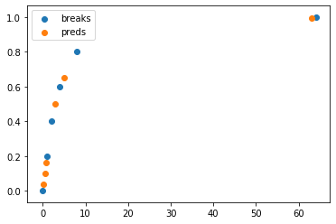

```python
brks = tensor(0,1,2,4,8,64).float()
ys = tensor(range_of(brks)).float()
ys /= ys[-1].item()
pts = tensor(0.2,0.5,0.8,3,5,63)

preds = pts.interp_1d(brks, ys)
test_close(preds.numpy(), np.interp(pts.numpy(), brks.numpy(), ys.numpy()))

plt.scatter(brks,ys)
plt.scatter(pts,preds)
plt.legend(['breaks','preds']);
```

`logit`[[source]](https://github.com/fastai/fastai2/tree/master/fastai2/torch_core.py#L357)

> `logit`(**`x`**)

Logit of `x`, clamped to avoid inf.

`num_distrib`[[source]](https://github.com/fastai/fastai2/tree/master/fastai2/torch_core.py#L363)

> `num_distrib`()

Return the number of processes in distributed training (if applicable).

`rank_distrib`[[source]](https://github.com/fastai/fastai2/tree/master/fastai2/torch_core.py#L368)

> `rank_distrib`()

Return the distributed rank of this process (if applicable).

`distrib_barrier`[[source]](https://github.com/fastai/fastai2/tree/master/fastai2/torch_core.py#L373)

> `distrib_barrier`()

Place a synchronization barrier in distributed training so that ALL sub-processes in the pytorch process group must arrive here before proceeding.

`Path.save_array`[[source]](https://github.com/fastai/fastai2/tree/master/fastai2/torch_core.py#L386)

> `Path.save_array`(**`p`**:`Path`, **`o`**, **`complib`**=*`'lz4'`*, **`lvl`**=*`3`*)

Save numpy array to a compressed `pytables` file, using compression level `lvl`

Compression lib can be any of: blosclz, lz4, lz4hc, snappy, zlib or zstd.

`Path.load_array`[[source]](https://github.com/fastai/fastai2/tree/master/fastai2/torch_core.py#L393)

> `Path.load_array`(**`p`**:`Path`)

Save numpy array to a `pytables` file

## Image helpers

`make_cross_image`[[source]](https://github.com/fastai/fastai2/tree/master/fastai2/torch_core.py#L399)

> `make_cross_image`(**`bw`**=*`True`*)

Create a tensor containing a cross image, either `bw` (True) or color

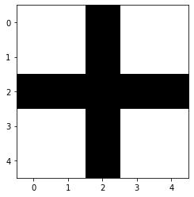

```python
plt.imshow(make_cross_image(), cmap="Greys");
```

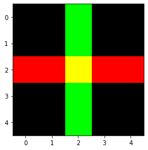

```python
plt.imshow(make_cross_image(False).permute(1,2,0));
```

`show_image_batch`[[source]](https://github.com/fastai/fastai2/tree/master/fastai2/torch_core.py#L412)

> `show_image_batch`(**`b`**, **`show`**=*`'show_titled_image'`*, **`items`**=*`9`*, **`cols`**=*`3`*, **`figsize`**=*`None`*, **`kwargs`)

Display batch `b` in a grid of size `items` with `cols` width

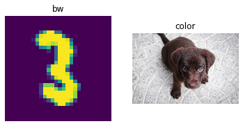

```python
show_image_batch(([Image.open(TEST_IMAGE_BW),Image.open(TEST_IMAGE)],['bw','color']), items=2)
```

## Model init

`requires_grad`[[source]](https://github.com/fastai/fastai2/tree/master/fastai2/torch_core.py#L421)

> `requires_grad`(**`m`**)

Check if the first parameter of `m` requires grad or not

```python
tst = nn.Linear(4,5)
assert requires_grad(tst)
for p in tst.parameters(): p.requires_grad_(False)
assert not requires_grad(tst)
```

`init_default`[[source]](https://github.com/fastai/fastai2/tree/master/fastai2/torch_core.py#L427)

> `init_default`(**`m`**, **`func`**=*`'kaiming_normal_'`*)

Initialize `m` weights with `func` and set `bias` to 0.

```python
tst = nn.Linear(4,5)
tst.weight.data.uniform_(-1,1)
tst.bias.data.uniform_(-1,1)
tst = init_default(tst, func = lambda x: x.data.fill_(1.))
test_eq(tst.weight, torch.ones(5,4))
test_eq(tst.bias, torch.zeros(5))
```

`cond_init`[[source]](https://github.com/fastai/fastai2/tree/master/fastai2/torch_core.py#L435)

> `cond_init`(**`m`**, **`func`**)

Apply `init_default` to `m` unless it's a batchnorm module

```python
tst = nn.Linear(4,5)
tst.weight.data.uniform_(-1,1)
tst.bias.data.uniform_(-1,1)
cond_init(tst, func = lambda x: x.data.fill_(1.))
test_eq(tst.weight, torch.ones(5,4))
test_eq(tst.bias, torch.zeros(5))

tst = nn.BatchNorm2d(5)
init = [tst.weight.clone(), tst.bias.clone()]
cond_init(tst, func = lambda x: x.data.fill_(1.))
test_eq(tst.weight, init[0])
test_eq(tst.bias, init[1])
```

`apply_leaf`[[source]](https://github.com/fastai/fastai2/tree/master/fastai2/torch_core.py#L440)

> `apply_leaf`(**`m`**, **`f`**)

Apply `f` to children of `m`.

```python
tst = nn.Sequential(nn.Linear(4,5), nn.Sequential(nn.Linear(4,5), nn.Linear(4,5)))
apply_leaf(tst, partial(init_default, func=lambda x: x.data.fill_(1.)))
for l in [tst[0], *tst[1]]: test_eq(l.weight, torch.ones(5,4))
for l in [tst[0], *tst[1]]: test_eq(l.bias,   torch.zeros(5))
```

`apply_init`[[source]](https://github.com/fastai/fastai2/tree/master/fastai2/torch_core.py#L447)

> `apply_init`(**`m`**, **`func`**=*`'kaiming_normal_'`*)

Initialize all non-batchnorm layers of `m` with `func`.

```python
tst = nn.Sequential(nn.Linear(4,5), nn.Sequential(nn.Linear(4,5), nn.BatchNorm1d(5)))
init = [tst[1][1].weight.clone(), tst[1][1].bias.clone()]
apply_init(tst, func=lambda x: x.data.fill_(1.))
for l in [tst[0], tst[1][0]]: test_eq(l.weight, torch.ones(5,4))
for l in [tst[0], tst[1][0]]: test_eq(l.bias,   torch.zeros(5))
test_eq(tst[1][1].weight, init[0])
test_eq(tst[1][1].bias,   init[1])
```

## Multiprocessing

`set_num_threads`[[source]](https://github.com/fastai/fastai2/tree/master/fastai2/torch_core.py#L455)

> `set_num_threads`(**`nt`**)

Get numpy (and others) to use `nt` threads

`class` `ProcessPoolExecutor`[[source]](https://github.com/fastai/fastai2/tree/master/fastai2/torch_core.py#L466)

> `ProcessPoolExecutor`(**`max_workers`**=*`None`*, **`on_exc`**=*`'print'`*, **`mp_context`**=*`None`*, **`initializer`**=*`None`*, **`initargs`**=*`()`*) :: `ProcessPoolExecutor`

This is an abstract base class for concrete asynchronous executors.

`parallel`[[source]](https://github.com/fastai/fastai2/tree/master/fastai2/torch_core.py#L480)

> `parallel`(**`f`**, **`items`**, *`args`, **`n_workers`**=*`64`*, **`total`**=*`None`*, **`progress`**=*`True`*, **`kwargs`)

Applies `func` in parallel to `items`, using `n_workers`

```python
def add_one(x, a=1):
    time.sleep(random.random()/100)
    return x+a

inp,exp = range(50),range(1,51)
test_eq(parallel(add_one, inp, n_workers=2), exp)
test_eq(parallel(add_one, inp, n_workers=0), exp)
test_eq(parallel(add_one, inp, n_workers=1, a=2), range(2,52))
test_eq(parallel(add_one, inp, n_workers=0, a=2), range(2,52))
```

`run_procs`[[source]](https://github.com/fastai/fastai2/tree/master/fastai2/torch_core.py#L490)

> `run_procs`(**`f`**, **`f_done`**, **`args`**)

Call `f` for each item in `args` in parallel, yielding `f_done`

`parallel_gen`[[source]](https://github.com/fastai/fastai2/tree/master/fastai2/torch_core.py#L499)

> `parallel_gen`(**`items`**, **`n_workers`**=*`64`*, **`as_gen`**=*`False`*, **`kwargs`)

Instantiate `cls` in `n_workers` procs & call each on a subset of `items` in parallel.

`cls` is any class with `__call__`. It will be passed `args` and `kwargs` when initialized. Note that `n_workers` instances of `cls` are created, one in each process. `items` are then split in `n_workers` batches and one is sent to each `cls`. The function then returns a list of all the results, matching the order of `items` (if not `as_gen`) or a generator of tuples of item indices and results (if `as_gen`).

```python
class SleepyBatchFunc:
    def __init__(self): self.a=1
    def __call__(self, batch):
        for k in batch:
            time.sleep(random.random()/4)
            yield k+self.a

x = np.linspace(0,0.99,20)
res = L(parallel_gen(SleepyBatchFunc, x, n_workers=2))
test_eq(res.sorted().itemgot(1), x+1)
```

## autograd jit functions

`script_use_ctx`[[source]](https://github.com/fastai/fastai2/tree/master/fastai2/torch_core.py#L510)

> `script_use_ctx`(**`f`**)

Decorator: create jit script and pass everything in `ctx.saved_variables to`f`, after`*args`

`script_save_ctx`[[source]](https://github.com/fastai/fastai2/tree/master/fastai2/torch_core.py#L517)

> `script_save_ctx`(**`static`**, *`argidx`)

Decorator: create jit script and save args with indices `argidx` using `ctx.save_for_backward`

`script_fwd`[[source]](https://github.com/fastai/fastai2/tree/master/fastai2/torch_core.py#L532)

> `script_fwd`(*`argidx`)

Decorator: create static jit script and save args with indices `argidx` using `ctx.save_for_backward`

`script_bwd`[[source]](https://github.com/fastai/fastai2/tree/master/fastai2/torch_core.py#L537)

> `script_bwd`(**`f`**)

Decorator: create static jit script and pass everything in `ctx.saved_variables to`f`, after`*args`

`grad_module`[[source]](https://github.com/fastai/fastai2/tree/master/fastai2/torch_core.py#L542)

> `grad_module`()

Decorator: convert `cls` into an autograd function